# Corso RMarkdown e Quarto

Author

Alessia Patti

Published

November 24, 2025

# 1 Vediamo il dataset

```r
library(readxl)
Sara = read_excel("Sara_dataset.xls")
Sara
```

```
# A tibble: 100 × 13
   gender major  cond phobia prevmath mathquiz statquiz hr_base hr_pre hr_post
    <dbl> <dbl> <dbl>  <dbl>    <dbl>    <dbl>    <dbl>   <dbl>  <dbl>   <dbl>
 1      1     1     1      1        3       43        6      71     68      65
 2      1     1     1      1        4       49        9      73     75      68
 3      1     1     1      4        1       26        8      69     76      72
 4      1     1     1      4        0       29        7      72     73      78
 5      1     1     1     10        1       31        6      71     83      74
 6      1     1     2      4        1       20        7      70     71      76
 7      1     1     2      4        2       13        3      71     70      66
 8      1     1     2      4        1       23        7      77     87      84
 9      1     1     2      4        1       38        8      73     72      67
10      1     1     2      5        0       NA        7      78     76      74
# ℹ 90 more rows
# ℹ 3 more variables: anx_base <dbl>, anx_pre <dbl>, anx_post <dbl>
```

# 2 Heart rate e ansia

## 2.1 Immagini

Variabili: Heart rate e ansia

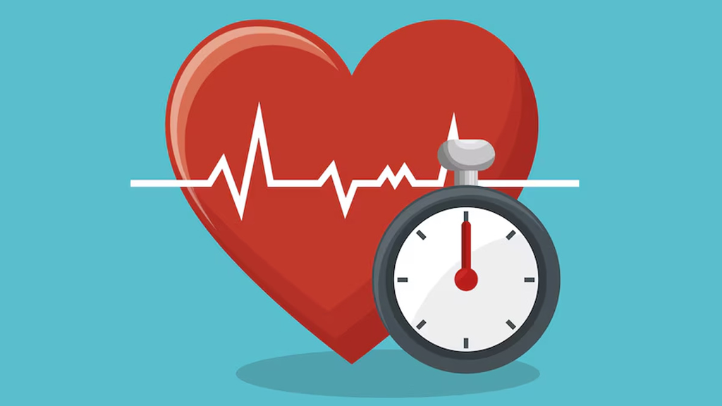

Figure 1: Heart rate

[figure not shown]

Figure 2: Ansia

## 2.2 Una rappresentazione dei dati

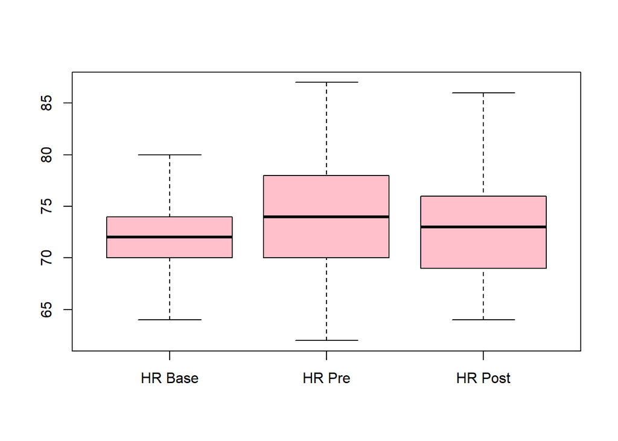

Livelli di heart rate nelle tre condizioni

```r
boxplot(
  Sara$hr_base, Sara$hr_pre, Sara$hr_post,
  names = c("HR Base","HR Pre","HR Post"),
  col = "pink"
)
```

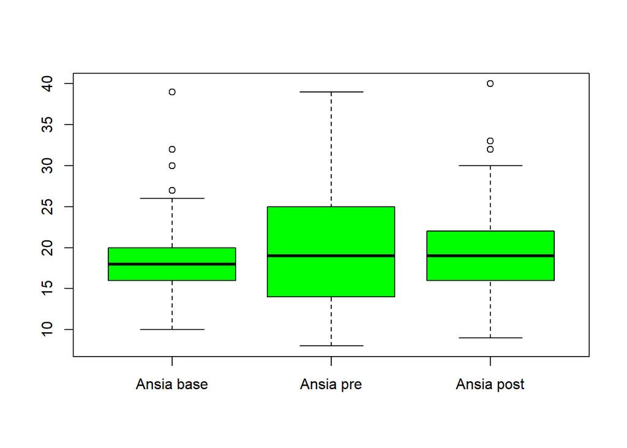

Livelli di ansia nelle tre condizioni

```r
boxplot(
  Sara$anx_base, Sara$anx_pre, Sara$anx_post,
  names = c("Ansia base","Ansia pre","Ansia post"),
  col = "green"
)
```

## 2.3 Heart rate e ansia: statistiche descrittive

```r
summary(Sara$hr_base)
```

```
   Min. 1st Qu.  Median    Mean 3rd Qu.    Max.
  64.00   70.00   72.00   72.27   74.00   80.00
```

```r
summary(Sara$hr_pre)
```

```
   Min. 1st Qu.  Median    Mean 3rd Qu.    Max.
  62.00   70.00   74.00   73.85   78.00   87.00
```

```r
summary(Sara$hr_post)
```

```
   Min. 1st Qu.  Median    Mean 3rd Qu.    Max.
   64.0    69.0    73.0    72.8    76.0    86.0
```

```r
sd(Sara$hr_base)
```

```
[1] 3.215666
```

```r
sd(Sara$hr_pre)
```

```
[1] 5.131355
```

```r
sd(Sara$hr_post)
```

```
[1] 4.739688
```

```r
summary(Sara$anx_base)
```

```
   Min. 1st Qu.  Median    Mean 3rd Qu.    Max.
  10.00   16.00   18.00   18.43   20.00   39.00
```

```r
summary(Sara$anx_pre)
```

```
   Min. 1st Qu.  Median    Mean 3rd Qu.    Max.
   8.00   14.00   19.00   19.58   25.00   39.00
```

```r
summary(Sara$anx_post)
```

```
   Min. 1st Qu.  Median    Mean 3rd Qu.    Max.
    9.0    16.0    19.0    19.4    22.0    40.0
```

```r
sd(Sara$anx_base)
```

```
[1] 4.33043
```

```r
sd(Sara$anx_pre)
```

```
[1] 6.432525
```

```r
sd(Sara$anx_post)
```

```
[1] 4.769431
```

### 2.3.1 Heart rate e ansia: una descrizione delle statistiche descrittive

La variabile “Heart Rate” rappresenta l’auto-misurazione del battito cardiaco in diverse situazioni, ovvero: in condizioni normali (HR base), prima di un test (HR pre-test) e dopo un test (HR post-test).

Nel seguente dataset, l’Heart Rate di base ha media 72.27 e deviazione standard 3.22, l’Heart Rate pre-test ha media 73.85 e deviazione standard 5.13 e, infine, l’Heart Rate post-test ha media pari a 72.8 e deviazione standard pari a 4.74.

La variabile “Ansia” rappresenta i livelli di ansia riportati dal soggetto ad un test sull’ansia in condizioni normali (ansia di base), prima di un test (ansia pre-test) e dopo un test (ansia post-test).

Nel dataset riportato, l’ansia di base ha media 18.43 e deviazione standard 4.33, l’ansia pre-test ha media 19.58 e deviazione standard 6.43, mentre l’ansia post-test ha media 19.4 e deviazione standard 4.77.

### 2.3.2 Un riassunto delle statistiche descrittive (media e deviazione standard) di Heart rate e ansia

Heart rate:

- Base: m=72.27 ; ds=3.22
- Pre-test: m=73.85 ; ds=5.13
- Post-test: m=72.8 ; ds=4.74

Ansia:

- Base: m=18.43 ; ds=4.33
- Pre-test: m=19.58 ; ds=6.43
- Post-test: m=19.4 ; 4.77

## 2.4 Letteratura scientifica

Secondo la letteratura scientifica, una situazione di stress psicologico provoca un aumento dell’Heart rate e dei livelli di ansia. Lo studio di Trotman et al. (2019), nello specifico, ha dimostrato che la frequenza cardiaca percepita, piuttosto che quella effettiva, è più strettamente associata all’intensità dell’ansia in una condizione di stress psicologico (Trotman et al., 2019).

# 3 Conclusioni

In questo lavoro sono state considerate le variabili relative all’Heart rate (Figura Figura 1) e all’ansia (Figura Figura 2), confrontandone i livelli prima e dopo l’esecuzione di un test e discutendo, infine, i risultati tenendo in considerazione la letteratura scientifica presente.

## References

Trotman, G. P., Veldhuijzen van Zanten, J. J., Davies, J., Möller, C., Ginty, A. T., & Williams, S. E. (2019). Associations between heart rate, perceived heart rate, and anxiety during acute psychological stress. *Anxiety, Stress, & Coping*, *32*(6), 711–727.